# MTH6139 Time Series

Coursework 1 – Forecasting with Meta’s Prophet Model

Syed Miah

17/03/2025

# **Introduction**

Time series forecasting plays a crucial role in predicting future trends across various industries, including finance, healthcare, and environmental sciences. In this project, we utilize *Meta’s Prophet Model*, a robust forecasting tool, to analyse a time series dataset and make future predictions.

Meta’s Prophet is an *open-source time-series analysis tool*, released to the public in February 2017. The purpose of Prophet is to handle time series data with strong seasonal effects and clear trends, making it useful for tasks like forecasting sales, electricity demand, and other time-dependent data.

In the following sections I will run through each of the steps I took to from preparing my chosen dataset to having a visual plot of the forecasting model. I will also explore and highlight any interesting features I find with my dataset and the model followed by my final thoughts on the data and the model.

# **Prepreparation of Libraries and Time Series**

## *Loading Necessary R Packages*

To start, I installed the necessary packages to run the forecasting model using `install.packages(prophet)`. I opted to use the default method of installing the model for simplicity and for easy replication. After installing, I loaded the package using `library(prophet)` along with the `library(zoo)` package, which I will utilise in the later sections.

## *Importing My Chosen Dataset*

Time Series datasets are among the most common in everyday life, as we measure countless variables against precious time. The dataset I have picked consists of *Retail Sales data spanning from 1992 to 2016*, and out of the many options aligned the most with my business and financial passion.

> The website I used to access this dataset, linked below, offers many more datasets to explore. Feel free to check it out and try Meta’s Prophet for yourself! https://github.com/facebook/prophet/tree/main/examples

```r
RetailSalesDataExample <- read.csv("data/RetailSalesDataExample.csv")
```

Importing the dataset was straight forward with the code I’ve used above.

## *Generating the Time Series Plot*

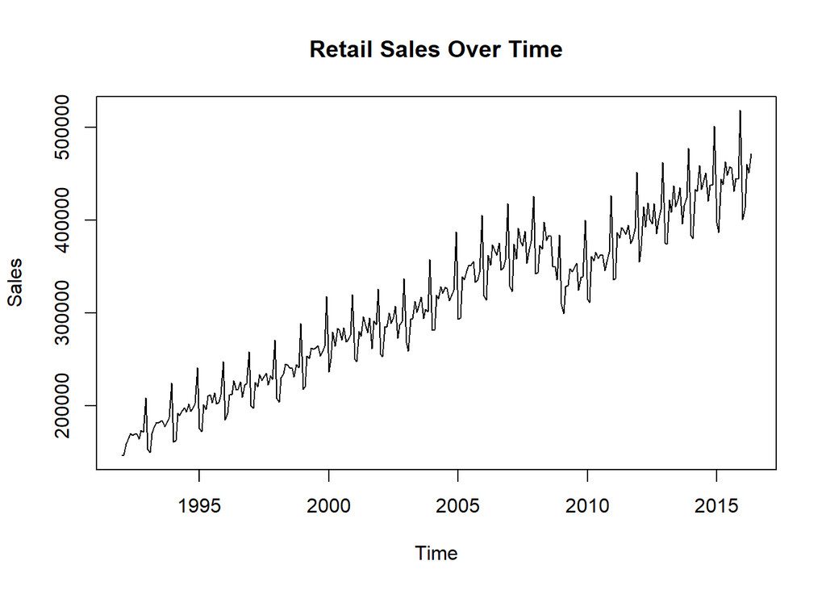

```r
RetailSales.DataFrame <- data.frame(
    ds = zoo::as.Date(RetailSalesDataExample$ds),
    y = RetailSalesDataExample$y)
options(scipen = 999)
plot(RetailSales.DataFrame$ds, RetailSales.DataFrame$y, type="l", xlab = "Time", ylab = "Sales",
     main = "Retail Sales Over Time")
```

I ensured the data was properly formatted by using a combination of `data.frame()` and `zoo()` to structure it correctly, ensuring the columns contained the appropriate *dates and numeric values*. One challenge I encountered was the y-axis representation, as R displayed large values in scientific notation *(which wasn’t visually appealing!)*. To address this, I used `options(scipen)` to force R to display the full numbers. Finally, a simple `plot()` function, with adjustments to the axis labels `xlab`, `ylab` and a good title using `main`, resulted in a *clear and well-structured plot*, ready for analysis in the next section.

## *My Initial Thoughts of Retail Sales Over Time*

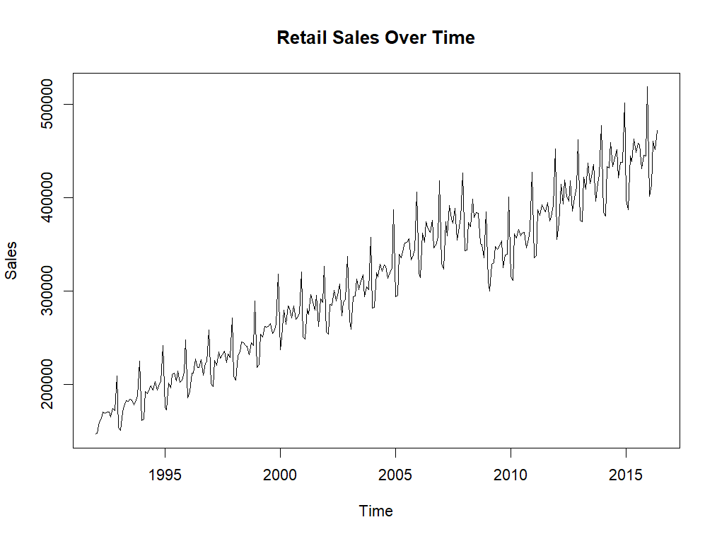

One particularly *notable feature* in this dataset is the *clear dip in 2008/2009*. This occurs with the *2008 Global Financial Crisis*, a well-documented period of economic downturn, clearly affecting retail sales performance.

# **Using Meta’s Forecasting Model**

## *Generating the Future Dataframe*

Predictions are generated from our Retail Sales dataframe mentioned earlier with the `ds` column containing dates for forecasting. The `make_future_dataframe()` function takes a trained model (**Our Historical Data**) and a specified number of periods to predict, creating a properly formatted dataframe. I have indentified further that the number of periods can be changed accordingly, for example i have set it to 730 to identify the trend for a following 2 years.

```r
FutureRetailSales <- make_future_dataframe(HistoricRetailSales, periods = 730)
```

## *Prophetic Predictions*

The `predict()` function is used to generate forecasts in Prophet. After training the model, `predict()` takes the future dates (created using `make_future_dataframe()`) and returns the forecasted (*predicted*) values. This allows analysis of both future predictions and the overall behaviour of the data.

```r
ForecastedRetailSales <- predict(HistoricRetailSales, FutureRetailSales)
```

## *Plotting the Forecast*

Finally we plot our findings for a visual idea of the tool.

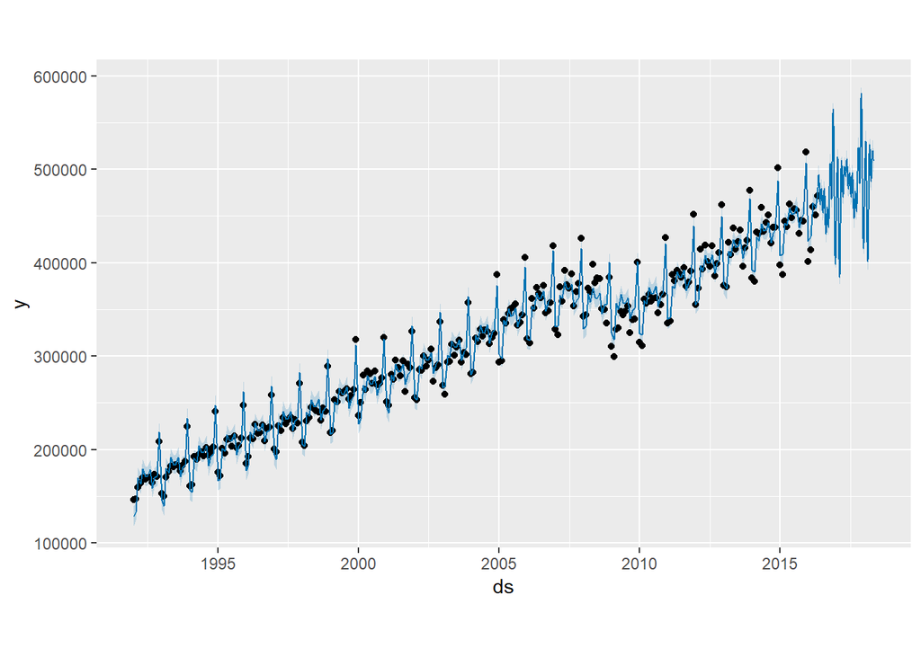

```r
plot(HistoricRetailSales, ForecastedRetailSales)
```

> It was important here to use clear labels to understand what the model needed and was processing. Historic, Future and Forecast rather than one letter!

# **Final Analysis and Thoughts**

## *Identifying Trends*

Further analyis can be carried out with the Prophet model:

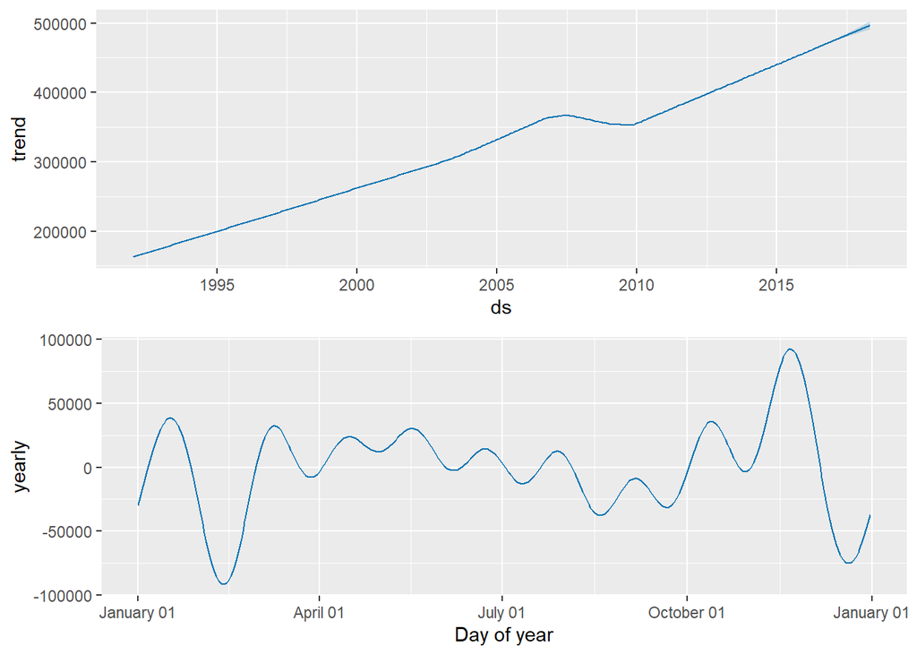

```r
prophet_plot_components(HistoricRetailSales, ForecastedRetailSales)
```

## *Final Thoughts on Meta’s Prophet*

This was my first experience working with many of the tools used in this project, including *R Markdown and Meta’s Prophet*. It has been an excellent hands-on learning experience, allowing me to work directly with the dataset and see how each line of R code results in meaningful insights and visualisations.

*Meta’s Prophet* is a powerful forecasting tool widely used across industries, and it has performed exceptionally well with my dataset. The model effectively captured both *trends and seasonality*, offering a reliable projection of future retail sales based on historical data. Given its accuracy and ease of use, I would definitely use it again and highly encourage others to explore its capabilities!